# BigDataAnalytics-Lab-1

Load gap and geo csvs.

```r
gap <- read.csv("/Users/harshilshah/Documents/tempR/gap.csv")
geo <- read.csv("/Users/harshilshah/Documents/tempR/geo.csv")
```

gap.csv contains pop. vs. year.

Get total population per year and plot.

Installed package dplyr on console.

by_year stores only YEAR and POPULATION variables from gap data frame. Then, group_by on YEAR to group all population together by year and the summarize function sums all those population values up into one entry per year.

Then, I use ggplot function to plot the by_year data with aesthetic values of x as year and y as population. I plot each point using geom_point() and a line through it for clarity using geom_line();

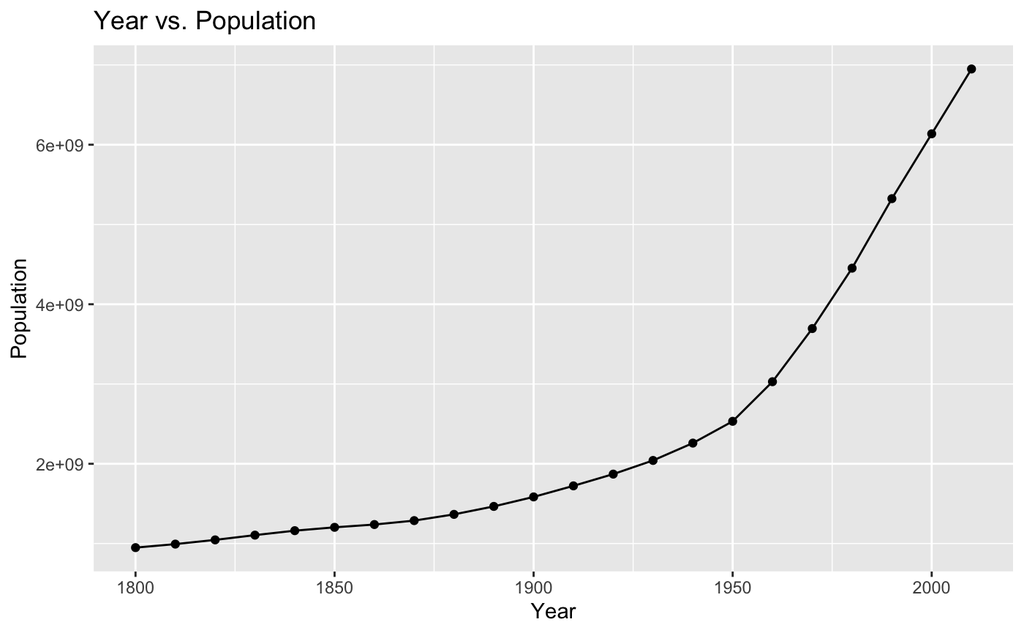

```r
library(dplyr)

by_year <- gap %>% select(year, population) %>% group_by(year) %>% summarize(population = sum(population), .groups='drop')

p <- ggplot(by_year, aes(x=year, y =population)) + geom_point() + geom_line()
p + labs(title = "Year vs. Population",
            x = "Year",
            y = "Population")
```

Then, take that data frame and group it again by year and summarize it using sum of total_gdp (added na.rm=TRUE for safety but not necessary)

Then plot it the same way as above.

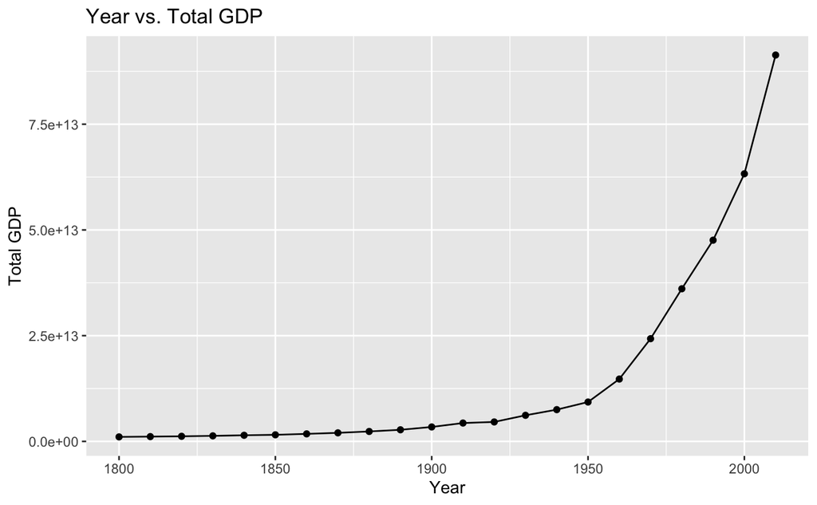

```r
by_year_gdp_df <- gap %>% select(year, population, gdp_percap) %>% transmute(year, total_gdp = population * gdp_percap, na.rm=TRUE)

grouped_total_gdp <- by_year_gdp_df %>% group_by(year) %>% summarize(final_total_gdp = sum(total_gdp, na.rm=TRUE), .groups='drop')

p <- ggplot(grouped_total_gdp, aes(x=year, y=final_total_gdp)) + geom_point() + geom_line()
p + labs(title = "Year vs. Total GDP",
            x = "Year",
            y = "Total GDP")
```